# WB

## Vote share change

Parties vote share as a function of SC/ST population.

### ST - BJP & AITC - 2016-19

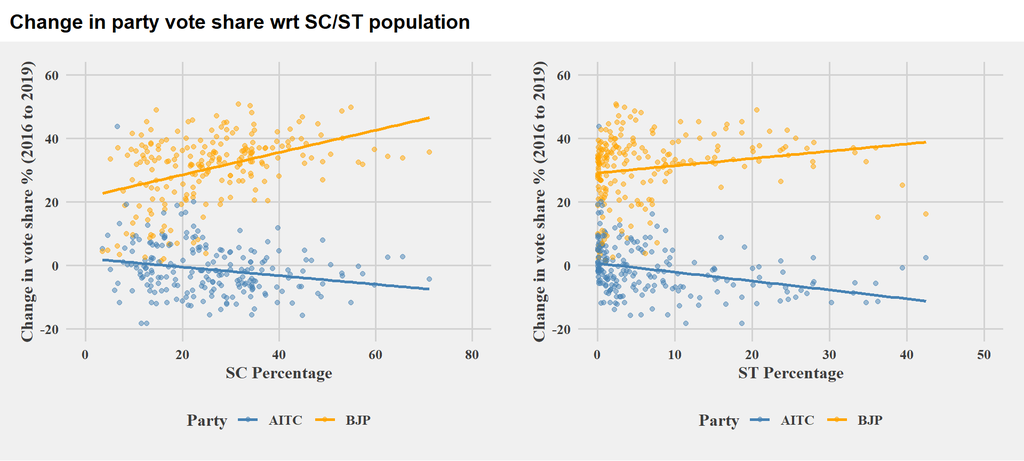

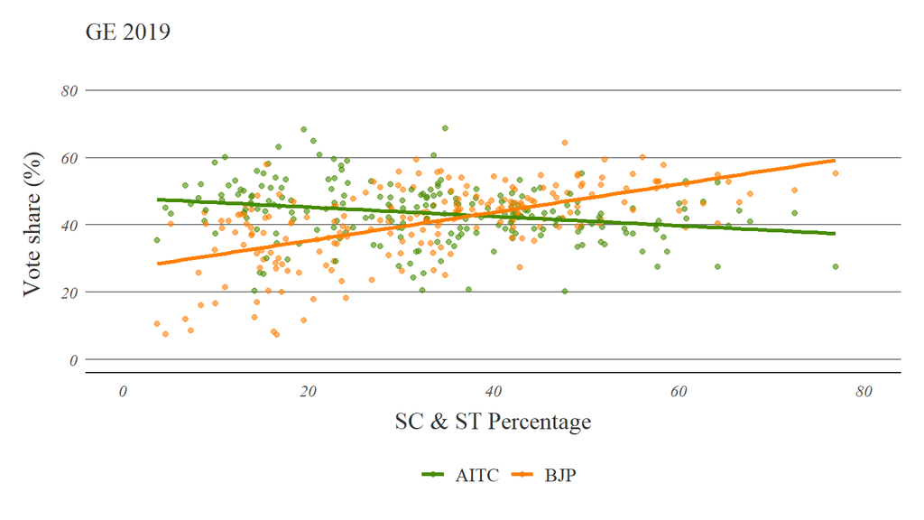

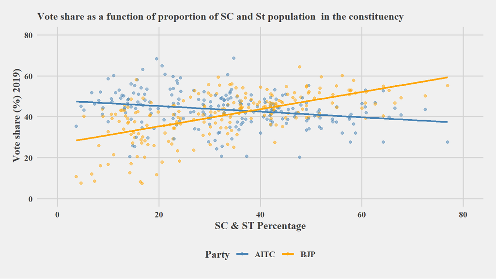

# Muslims

Muslims percentage at AC level aggregated using Raphael’s booth level data.

## District level distribution

| Muslim percentage cat | Count of AC | Percentage of ACs |
| --- | --- | --- |
| (0,20] | 1 | 0.36 |
| (20,30] | 56 | 20.44 |
| (30,40] | 98 | 35.77 |
| (40,50] | 88 | 32.12 |
| (50,Inf] | 31 | 11.31 |

## Vote share

### All AE and GE elections- Post 2009

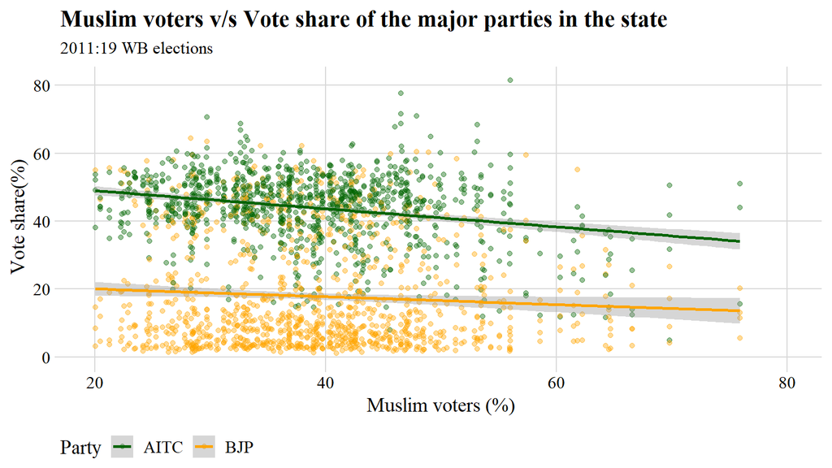

### AE elections

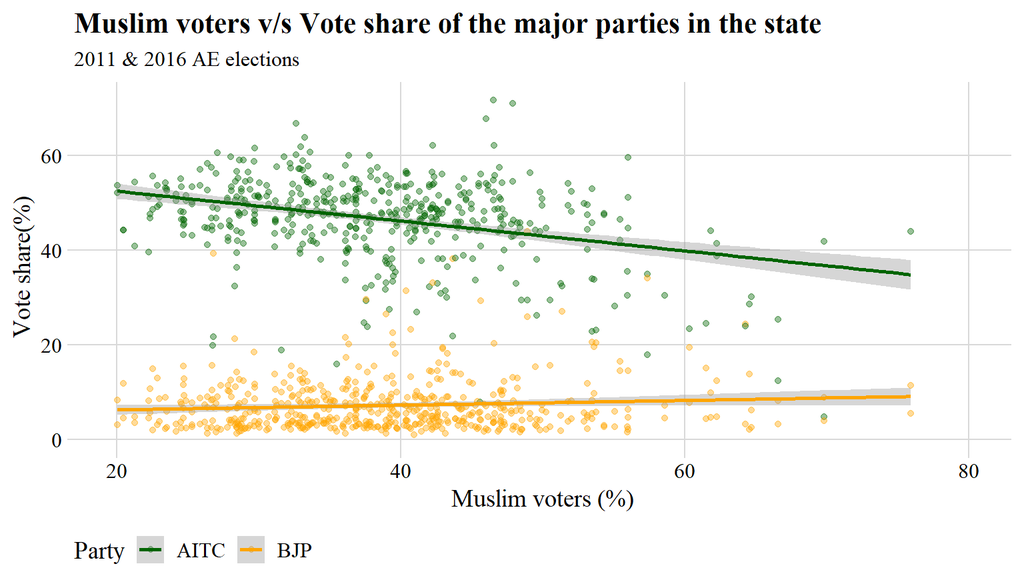

### GE elections

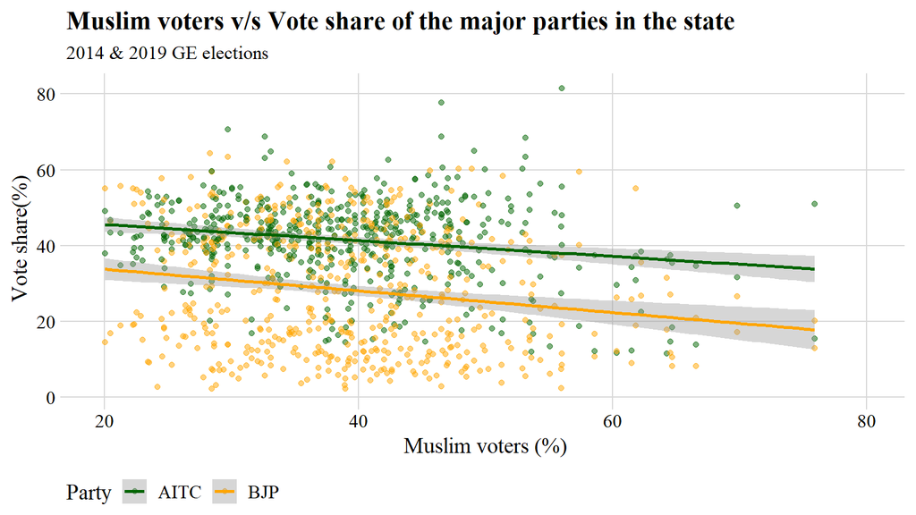

### 2019- AITC & BJP

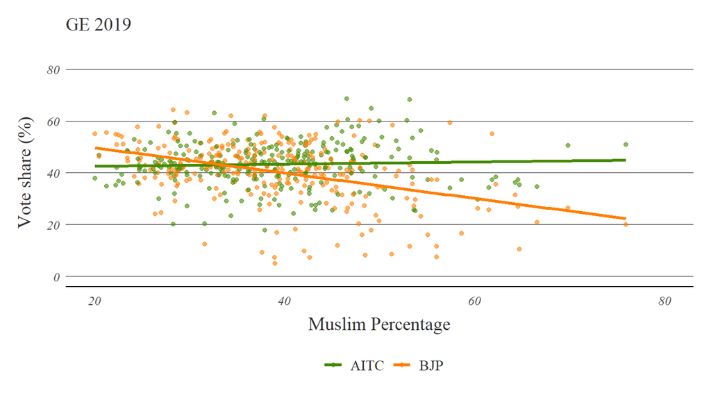

### 2019 - AITC

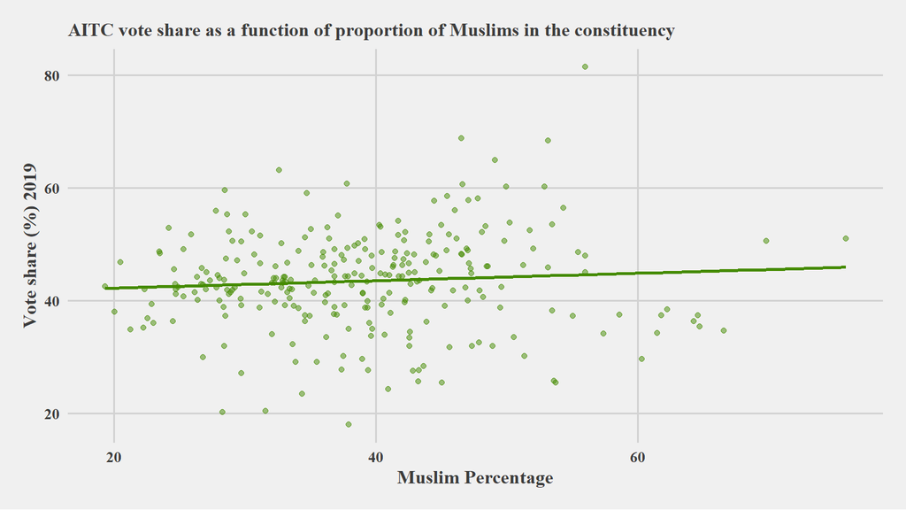

## Vote share change

Paarty vote share change from 2016 as a function of Muslim population

### Vote share change - ATIC & BJP

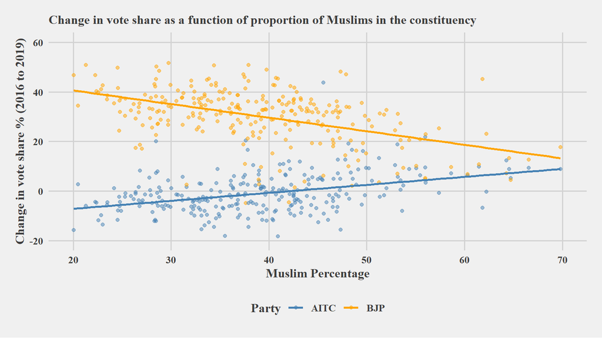

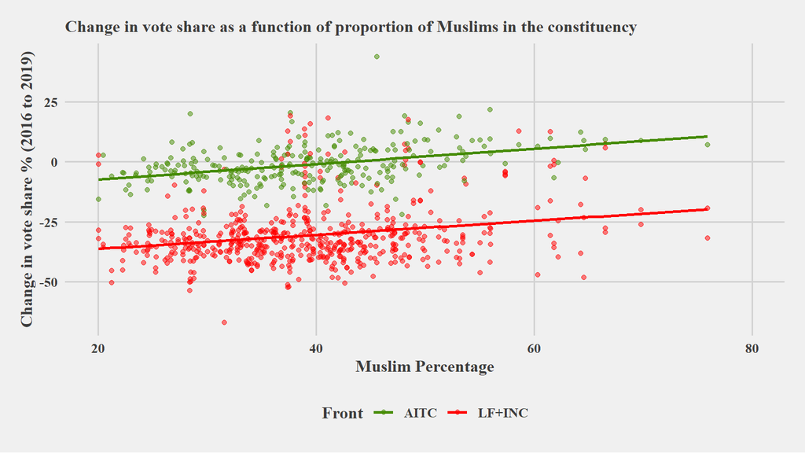

### Vote share change - ATIC

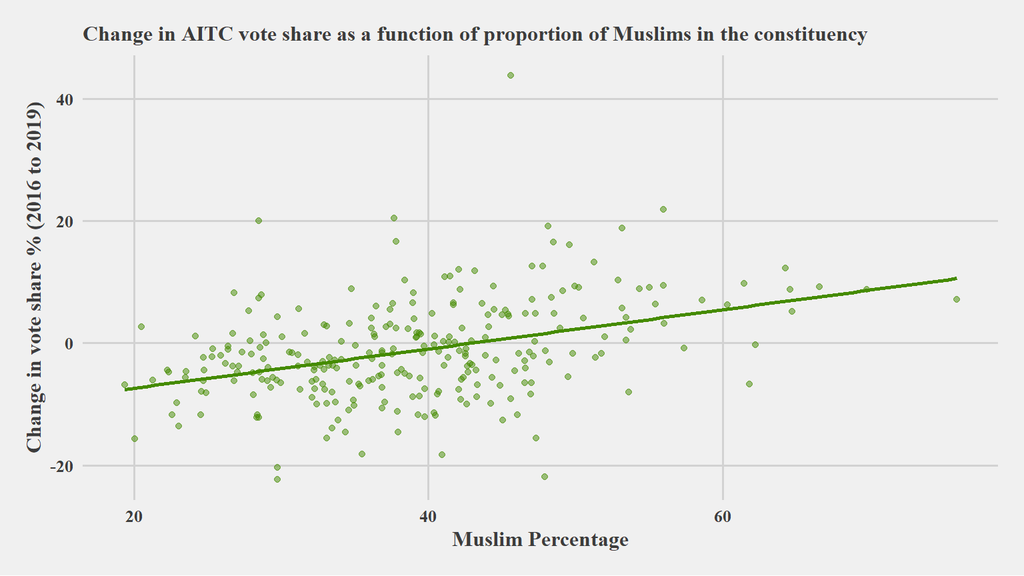

# sub region

## Count

| sub_region_rv | ac_count |
| --- | --- |
| Central Bengal | 33 |
| Hills | 27 |
| Jangalmahal | 40 |
| North Bengal | 27 |
| South-Central Bengal | 60 |
| South Bengal | 107 |

## Muslims by region

| sub_region_rv | mean_muslims |
| --- | --- |
| Central Bengal | 44.79 |
| Hills | 36.10 |
| Jangalmahal | 35.86 |
| North Bengal | 51.14 |
| South-Central Bengal | 35.93 |
| South Bengal | 37.39 |

## Constituency type

| sub_region_rv | GEN | SC/ST |
| --- | --- | --- |
| Central Bengal | 27 | 6 |
| Hills | 10 | 17 |
| Jangalmahal | 24 | 16 |
| North Bengal | 19 | 8 |
| South-Central Bengal | 44 | 16 |
| South Bengal | 86 | 21 |

## Vote share

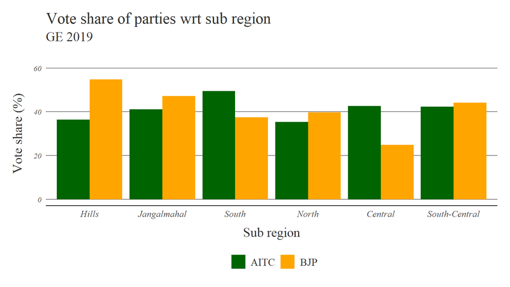

- it seems that south-central bengal is where BJP and AITC having a head to head competition.

## Seat share

| year | party | Central Bengal | Hills | Jangalmahal | North Bengal | South-Central Bengal | South Bengal |
| --- | --- | --- | --- | --- | --- | --- | --- |
| 2016 | AITC | 13 | 18 | 31 | 6 | 48 | 95 |
| 2016 | BJP | 0 | 1 | 1 | 1 | 0 | 0 |
| 2019 | AITC | 22 | 3 | 10 | 10 | 30 | 89 |
| 2019 | BJP | 6 | 24 | 30 | 13 | 30 | 18 |

## tunrout

| sub_region_rv | 2016 | 2019 |
| --- | --- | --- |
| Central Bengal | 83.22 | 81.79 |
| Hills | 83.99 | 81.96 |
| Jangalmahal | 85.59 | 83.32 |
| North Bengal | 82.71 | 80.20 |
| South-Central Bengal | 83.82 | 81.46 |
| South Bengal | 81.07 | 78.73 |

# districts

```
## # A tibble: 8 x 4
## # Groups:   district_name.y [8]
##   district_name.y      n_ac  AITC   BJP
##   <chr>               <int> <int> <dbl>
## 1 BARDHAMAN              25    14    11
## 2 HOOGHLY                18    10     8
## 3 HOWRAH                 16    15     1
## 4 KOLKATA CORPORATION    11     8     3
## 5 NADIA                  17     6    11
## 6 NORTH 24 PARGANAS      33    21    12
## 7 PURBA MEDINIPUR        16    14     2
## 8 SOUTH 24 PARGANAS      31    31     0
```

# South Bengal

## Party vote share

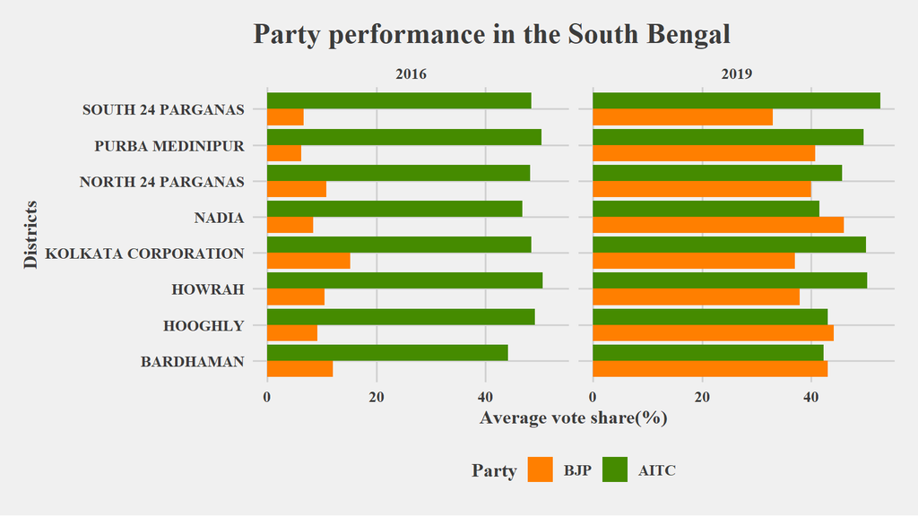

## Party seats

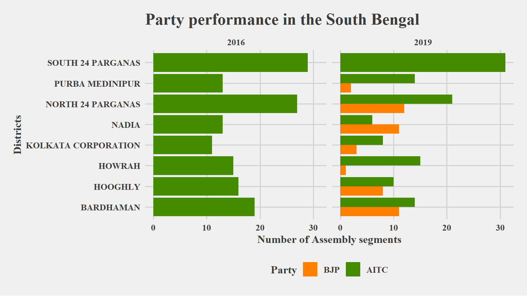

# South Bengal - BJP 2019

- New division

| Region | Front | Number of ACs leading | Number of ACs in the region | % of ACs leading in the region | Vote share of the front |
| --- | --- | --- | --- | --- | --- |
| Bengal - other | AITC | 75 | 187 | 40.11 | 40.45 |
| Bengal - other | BJP | 103 | 187 | 55.08 | 42.46 |
| Bengal - other | LF+INC | 9 | 187 | 4.81 | 14.40 |
| South Bengal | AITC | 89 | 107 | 83.18 | 49.73 |
| South Bengal | BJP | 18 | 107 | 16.82 | 37.20 |

**List of ACs in south Bengal with vote share of the fronts**

|  | constituency_no | constituency_name | LF+INC | AITC | BJP |
| --- | --- | --- | --- | --- | --- |
| 1 | 94 | Bagdah | 1 | 41.2 | 53 |
| 2 | 95 | Bongaon Uttar | 1.2 | 38.9 | 53.3 |
| 3 | 96 | Bongaon Dakshin | 0.9 | 39.4 | 54 |
| 4 | 97 | Gaighata | 1.1 | 36.8 | 54.7 |
| 5 | 98 | Swarupnagar (SC) | 4.5 | 47.3 | 35 |
| 6 | 99 | Baduria | 6.9 | 48.2 | 28.2 |
| 7 | 100 | Habra | 0.1 | 40.4 | 50.5 |
| 8 | 101 | Ashoknagar | 0.1 | 46.3 | 39.6 |
| 9 | 102 | Amdanga | 1.7 | 50.9 | 32 |
| 10 | 103 | Bijpur | 1.4 | 39.2 | 45.3 |

[output cut: 97 more lines]

# Vote share change - assumption models

## South Bengal

### BJP - addition

**How does change in certain percentage point vote share reflects on the number of constituencies led by BJP**

- Based on the new south bengal division

| Vote share added | Number of ACs leading | Percentage of leading ACs in south |
| --- | --- | --- |
| winner | 18 | 16.82 |
| winner_1pc | 22 | 20.56 |
| winner_2pc | 23 | 21.50 |
| winner_3pc | 27 | 25.23 |
| winner_5pc | 31 | 28.97 |
| winner_7pc | 40 | 37.38 |
| winner_10pc | 51 | 47.66 |

### AITC -reduction

**How does change in certain percentage point reduction in vote share reflects on the number of constituencies led by AITC**

- Based on the new south bengal division

| Vote share reduced | Number of ACs leading | Percentage of leading ACs in south |
| --- | --- | --- |
| winner | 89 | 83.18 |
| winner_1pc | 85 | 79.44 |
| winner_2pc | 84 | 78.50 |
| winner_3pc | 80 | 74.77 |
| winner_5pc | 76 | 71.03 |
| winner_7pc | 66 | 61.68 |
| winner_10pc | 55 | 51.40 |

## Pan bengal model

### BJP - addition

| Vote share added | Number of ACs leading | Percentage of leading ACs in WB |
| --- | --- | --- |
| winner | 121 | 41.16 |
| winner_1pc | 130 | 44.22 |
| winner_2pc | 140 | 47.62 |
| winner_3pc | 153 | 52.04 |
| winner_5pc | 162 | 55.10 |
| winner_7pc | 176 | 59.86 |
| winner_10pc | 195 | 66.33 |

### AITC - reduction

[output not shown]

## South and rest of the Bengal

### BJP - addition

| Vote share added | Nn_ACs leading in rest of the Bengal | % of leading ACs in rest of the Bengal | n_ACs leading in South Bengal | % of leading ACs in South Bengal |
| --- | --- | --- | --- | --- |
| winner | 103 | 55.08 | 18 | 16.82 |
| winner_1pc | 108 | 57.75 | 22 | 20.56 |
| winner_2pc | 117 | 62.57 | 23 | 21.50 |
| winner_3pc | 126 | 67.38 | 27 | 25.23 |
| winner_5pc | 131 | 70.05 | 31 | 28.97 |
| winner_7pc | 136 | 72.73 | 40 | 37.38 |
| winner_10pc | 144 | 77.01 | 51 | 47.66 |

### AITC - reduction

[output not shown]